# scientific-programming

## Data Type & Operators

```python
3+7
```

```
10
```

```python
15 / 3 * 5
```

```
25
```

```python
5 / 2
```

```
2
```

```python
5.0 / 2
```

```
2.5
```

Try out some of the following math operators by yourself: + - * / ** % == > < != <=

```python
#Just type in here ;-)
```

```python
2+'7'
```

```
---------------------------------------------------------------------------
TypeError                                 Traceback (most recent call last)
<ipython-input-6-5b3f048eab6c> in <module>()
----> 1 2+'7'

TypeError: unsupported operand type(s) for +: 'int' and 'str'
```

```python
"7"+"4"
```

```
'74'
```

```python
'3'+"a"
```

```
'3a'
```

```python
"Mixing 'up' " + "quotes"
```

```
"Mixing 'up' quotes"
```

```python
"4+7" * 3
```

```
'4+74+74+7'
```

```python
#And here again some space for you to try some things!
```

## Variables & Functions

```python
x=2
print(x)
```

```
2
```

```python
5 / int("2")
```

```
2
```

```python
#save 2 in variable "a" and 7 in "b" and calculate (by editing it):
a+b
a/b
int(a/b)
float(a)/b
```

Try some of those functions by yourself: abs(), int(), float(), str(), len(), type(), max(), min(), print(), += =+

## Lists & Dictionaries

```python
mylist = ['abc', 'def', 'ABC', 'DEF']
print(mylist)
mylist[2]
mylist[:-1]
```

```
['abc', 'def', 'ABC', 'DEF']
```

```
['abc', 'def', 'ABC']
```

```python
mylist + 'string'
print(mylist)
```

```
---------------------------------------------------------------------------
TypeError                                 Traceback (most recent call last)
<ipython-input-16-01e5adbe196d> in <module>()
----> 1 mylist + 'string'
      2 print(mylist)

TypeError: can only concatenate list (not "str") to list
```

```python
mylist += ['string']
print(mylist)
```

```
['abc', 'def', 'ABC', 'DEF', 'string']
```

```python
len(mylist[2:])
```

```
3
```

```python
range(4)
range(2,4)
```

```
[2, 3]
```

```python
c=['a']
c.append(2)
print(c)
```

```
['a', 2]
```

```python
#try something out again ;-)
```

```python
mydict = {
    'one': 1,
    'two': 2,
    'three': 3,
    'four': 4,
    'five': 5
}
print(mydict)
```

```
{'four': 4, 'three': 3, 'five': 5, 'two': 2, 'one': 1}
```

```python
mydict[3]
```

```
---------------------------------------------------------------------------
KeyError                                  Traceback (most recent call last)
<ipython-input-23-abe9d6404b7b> in <module>()
----> 1 mydict[3]

KeyError: 3
```

```python
mydict['three']
```

```
3
```

```python
mydict['six']=6
```

```python
#do it yourself!
```

## is Statements

```python
a=5
if a ==5:
    print('Yes, the input is', a)
```

```
('Yes, the input is', 5)
```

```python
a=3
b=4
if a > b:
    print('a is greater than b')
elif a < b:
    print('a is smaller than b')
else:
    print('a has the same value as b')
```

```
a is smaller than b
```

```python
#try it out yourself!
```

## Loops

```python
a=5
while a>0:
    print(a)
    a -= 1
```

```
5
4
3
2
1
```

```python
mylist = [3,4,7,2,9]
for item in mylist:
    print(item)
```

```
3
4
7
2
9
```

```python
for index, item in enumerate(mylist):
    print(index, item)
```

```
(0, 3)
(1, 4)
(2, 7)
(3, 2)
(4, 9)
```

```python
#add a fitting print to name what this function does
mylist = [2,4,7,2,9]
for index, item in enumerate(mylist):
    if item % 2 == 0:
        pass
    elif item % 2 ==1:
        continue
print('' + index + '' + item)
```

```
---------------------------------------------------------------------------
TypeError                                 Traceback (most recent call last)
<ipython-input-33-d6d0d37ce5da> in <module>()
      6     elif item % 2 ==1:
      7         continue
----> 8 print('' + index + '' + item)

TypeError: cannot concatenate 'str' and 'int' objects
```

try out some of the functions: pass, continue, break, +=, -=, *=, /=

## Functions

```python
def quad(a):
    return a*a
print(quad(5.6))
```

```
31.36
```

```python
def incr(myvar=4):
    myvar += 1

myvar = 5
print(incr(myvar))
print(myvar)
print(incr())
```

```
None
5
None
```

```python
#Is this function correct?
def num_particles(concentration, volume):
    """Given a molar concentration in mol/L and volume
    in cubic angstroms, returns the number of particles"""
    avogadro_num = 6.022E23
    angstrom_to_liters = 1E-27
    particles_per_liter = concentration * avogadro_num
    liters = volume * angstrom_to_liters

    return particles_per_liter * liters

# example usage
prompts = [
    "Molar concentration (moles/liter): ",
    "Volume (cubic angstroms): "
]

user_input = [float(input(prompt)) for prompt in prompts]

print("Number of particles:", num_particles(*user_input))
```

```
Molar concentration (moles/liter): 50
Volume (cubic angstroms): 4
('Number of particles:', 0.12044000000000002)
```

Make your own program which calculates the fibonacci numbers, e.g. for fib(6)=8

Fibonacci:

step1: 0 #initial

step2: 1 #initial

step3: 1 #step1 + step2

step4: 2 #step2 + step3

step5: 3 #step3 + step4

step6: 5 #step4 + step5

step7: 8 #step5 + step6

```python
#type it in here
```

## Classes and their Methods

Try out what these methods do to strings: upper(), lower(), find(), join(), replace(), split(), strip()

Try out what these methods do to lists: index(), pop(), reverse(), sort(), keys(), items(), find(), ...

# Plotting

```python
import matplotlib.pyplot as plt
import matplotlib.mlab as mlab
from scipy.interpolate import spline
import numpy as np

%pylab inline


def errorbarplotting(x, y, std_y, title="", xlabel="", ylabel="", everyerror=0, x_ticks=[]):

    fig, ax = plt.subplots(figsize=(10, 5))
    plt.tick_params(labelsize=20)

    x_sm = np.array(x)
    y_sm = np.array(y)

    for index, elem in enumerate(std_y):
        if elem < 0:
            std_y[index] = elem*-1
    std_sm = np.array(std_y)

    if everyerror !=0:
        plt.errorbar(x_sm, y_sm, yerr=std_sm, errorevery=everyerror)
    else:
        plt.errorbar(x_sm, y_sm, yerr=std_sm)
    plt.title(title, fontsize=20)
    plt.xlabel(xlabel, fontsize=20)
    plt.ylabel(ylabel, fontsize=20)
    if x_ticks != []:
        plt.xticks(np.arange(len(x_ticks)), x_ticks, fontsize=20)
    plt.show()


def smooth_errorareaplotting(x, y, std_y, std_y2=[], title="", xlabel="", ylabel="", x_ticks=[]):

    fig, ax = plt.subplots(figsize=(10, 5))
    plt.tick_params(labelsize=20)

    x_sm = np.array(x)
    y_sm = np.array(y)
    std_sm = np.array(std_y)

    x_smooth = np.linspace(x_sm.min(), x_sm.max(), 200)
    y_smooth = spline(x_sm, y_sm, x_smooth)

    if std_y2 == []:
        yu = np.zeros(len(std_sm))
        yd = np.zeros(len(std_sm))
        for index, elem in enumerate(std_sm):
            if elem >= 0:
                yu[index] = y_sm[index]-elem
                yd[index] = y_sm[index]+elem
            else:
                yd[index] = y_sm[index]-elem
                yu[index] = y_sm[index]+elem
    else:
        yu = np.array(std_sm)
        std2_sm = np.array(std_y2)
        yd = np.array(std2_sm)

    yu_smooth = spline(x_sm, yu, x_smooth)
    yd_smooth = spline(x_sm, yd, x_smooth)

    plt.plot(x_smooth, y_smooth, 'black', linewidth=1)

    plt.fill_between(x_smooth, yu_smooth, yd_smooth, facecolor='lightgrey', alpha=0.5, interpolate=True)
    plt.grid(True)
    plt.title(title, fontsize=20)
    plt.xlabel(xlabel, fontsize=20)
    plt.ylabel(ylabel, fontsize=20)
    if x_ticks != []:
        plt.xticks(np.arange(len(x_ticks)), x_ticks, fontsize=20)
    plt.show()
```

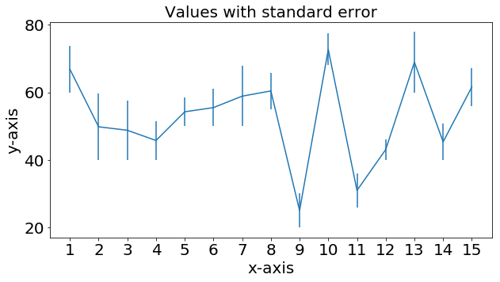

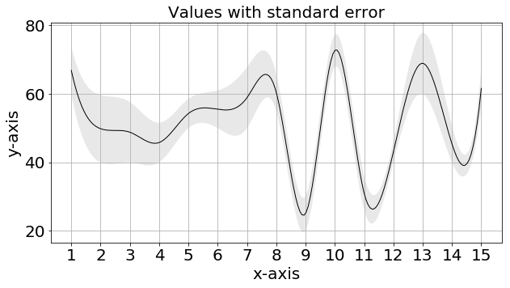

```python
# example data
y = np.array([ 66.8637326,   49.8347506,   48.80588268,  45.7843023,   54.26200578,
      55.50872359,  58.88869634,  60.42992473,  25.07767142,  72.69434382,
      31.01718311,  43.10311762,  68.9334629,   45.37133993,  61.609675  ])
x = range(0, len(y))
std_y = np.array([-6.8637326,   9.8347506,   8.80588268,  -5.7843023,   4.26200578,
      5.50872359,  -8.88869634,  5.42992473,  5.07767142,  -4.69434382,
      5.01718311,  3.10311762,  -8.9334629,   5.37133993,  5.609675])
x_ticks = ['1', '2', '3', '4', '5', '6', '7', '8', '9', '10', '11', '12', '13', '14', '15']

errorbarplotting(x, y, std_y, title="Values with standard error", xlabel="x-axis", ylabel="y-axis", x_ticks=x_ticks)
smooth_errorareaplotting(x, y, std_y, title="Values with standard error", xlabel="x-axis", ylabel="y-axis", x_ticks=x_ticks)
```

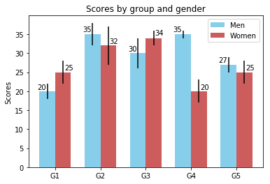

```python
import numpy as np
import matplotlib.pyplot as plt

men_means, men_std = (20, 35, 30, 35, 27), (2, 3, 4, 1, 2)
women_means, women_std = (25, 32, 34, 20, 25), (3, 5, 2, 3, 3)

ind = np.arange(len(men_means))  # the x locations for the groups
width = 0.35  # the width of the bars

fig, ax = plt.subplots()
rects1 = ax.bar(ind - width/2, men_means, width, yerr=men_std,
                color='SkyBlue', label='Men')
rects2 = ax.bar(ind + width/2, women_means, width, yerr=women_std,
                color='IndianRed', label='Women')

# Add some text for labels, title and custom x-axis tick labels, etc.
ax.set_ylabel('Scores')
ax.set_title('Scores by group and gender')
ax.set_xticks(ind)
ax.set_xticklabels(('G1', 'G2', 'G3', 'G4', 'G5'))
ax.legend()


def autolabel(rects, xpos='center'):
    """
    Attach a text label above each bar in *rects*, displaying its height.

    *xpos* indicates which side to place the text w.r.t. the center of
    the bar. It can be one of the following {'center', 'right', 'left'}.
    """

    xpos = xpos.lower()  # normalize the case of the parameter
    ha = {'center': 'center', 'right': 'left', 'left': 'right'}
    offset = {'center': 0.5, 'right': 0.57, 'left': 0.43}  # x_txt = x + w*off

    for rect in rects:
        height = rect.get_height()
        ax.text(rect.get_x() + rect.get_width()*offset[xpos], 1.01*height,
                '{}'.format(height), ha=ha[xpos], va='bottom')


autolabel(rects1, "left")
autolabel(rects2, "right")

plt.show()
```

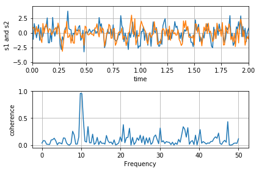

```python
import numpy as np
import matplotlib.pyplot as plt

# Fixing random state for reproducibility
np.random.seed(196801)

dt = 0.01
t = np.arange(0, 30, dt)
nse1 = np.random.randn(len(t))                 # white noise 1
nse2 = np.random.randn(len(t))                 # white noise 2

# Two signals with a coherent part at 10Hz and a random part
s1 = np.sin(2 * np.pi * 10 * t) + nse1
s2 = np.sin(2 * np.pi * 10 * t) + nse2

fig, axs = plt.subplots(2, 1)
axs[0].plot(t, s1, t, s2)
axs[0].set_xlim(0, 2)
axs[0].set_xlabel('time')
axs[0].set_ylabel('s1 and s2')
axs[0].grid(True)

cxy, f = axs[1].cohere(s1, s2, 256, 1. / dt)
axs[1].set_ylabel('coherence')

fig.tight_layout()
plt.show()
```

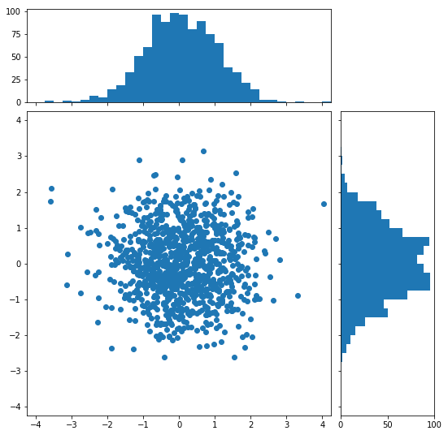

```python
import numpy as np
import matplotlib.pyplot as plt
from matplotlib.ticker import NullFormatter

# Fixing random state for reproducibility
np.random.seed(19680801)


# the random data
x = np.random.randn(1000)
y = np.random.randn(1000)

nullfmt = NullFormatter()         # no labels

# definitions for the axes
left, width = 0.1, 0.65
bottom, height = 0.1, 0.65
bottom_h = left_h = left + width + 0.02

rect_scatter = [left, bottom, width, height]
rect_histx = [left, bottom_h, width, 0.2]
rect_histy = [left_h, bottom, 0.2, height]

# start with a rectangular Figure
plt.figure(1, figsize=(8, 8))

axScatter = plt.axes(rect_scatter)
axHistx = plt.axes(rect_histx)
axHisty = plt.axes(rect_histy)

# no labels
axHistx.xaxis.set_major_formatter(nullfmt)
axHisty.yaxis.set_major_formatter(nullfmt)

# the scatter plot:
axScatter.scatter(x, y)

# now determine nice limits by hand:
binwidth = 0.25
xymax = max(np.max(np.abs(x)), np.max(np.abs(y)))
lim = (int(xymax/binwidth) + 1) * binwidth

axScatter.set_xlim((-lim, lim))
axScatter.set_ylim((-lim, lim))

bins = np.arange(-lim, lim + binwidth, binwidth)
axHistx.hist(x, bins=bins)
axHisty.hist(y, bins=bins, orientation='horizontal')

axHistx.set_xlim(axScatter.get_xlim())
axHisty.set_ylim(axScatter.get_ylim())

plt.show()
```

Check out some other ways to plot data: https://matplotlib.org/

# Visualizing Structures

Check out https://www.rcsb.org/, PyMOL, VMD, nglview

```python
import nglview
view=nglview.show_pdbid("3dqb")
view
```

```python
view.clear_representations()
view.add_surface('.CA', opacity=0.3)
```

```python
import mdtraj
traj = mdtraj.load(nglview.datafiles.TRR, top=nglview.datafiles.PDB)
view2 = nglview.show_mdtraj(traj)
view2
```

```python
print(traj)
topology = traj.topology
print(topology)
atom = topology.atom(10)
print('''Hi! I am the %sth atom, and my name is %s.
I am a %s atom with %s bonds.
I am part of an %s residue.''' % ( atom.index, atom.name, atom.element.name, atom.n_bonds, atom.residue.name))
```

```
<mdtraj.Trajectory with 51 frames, 5547 atoms, 349 residues, and unitcells>
<mdtraj.Topology with 1 chains, 349 residues, 5547 atoms, 5480 bonds>
Hi! I am the 10th atom, and my name is CB.
I am a carbon atom with 4 bonds.
I am part of an MET residue.
```

```
<mdtraj.Trajectory with 20 frames, 423 atoms, 28 residues, without unitcells>
GLU1-N -- GLU1-OE2
GLU1-N -- GLU1-OE1
GLY6-N -- SER4-O
CYS7-N -- GLY5-O
TYR11-N -- VAL8-O
MET12-N -- LYS20-O
ARG13-NH1 -- TYR11-O
THR14-N -- ARG18-O
ASP16-N -- ASP16-OD1
GLY17-N -- THR14-O
ARG18-N -- THR14-OG1
ARG18-NE -- ASP16-OD2
LYS20-N -- MET12-O
THR22-N -- GLY10-O
THR14-OG1 -- ASP16-OD1
THR28-OG1 -- ILE27-O
```

```
Text(0.5,0,'Donor-acceptor distance [nm]')
```

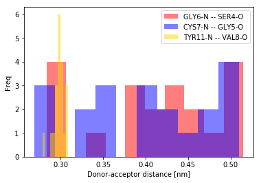

```python
from __future__ import print_function
%matplotlib inline
import matplotlib.pyplot as plt
import itertools
import mdtraj as md
import mdtraj.testing

t = md.load_pdb('http://www.rcsb.org/pdb/files/2EQQ.pdb')
print(t)
hbonds = md.baker_hubbard(t, periodic=False)
label = lambda hbond : '%s -- %s' % (t.topology.atom(hbond[0]), t.topology.atom(hbond[2]))
for hbond in hbonds:
    print(label(hbond))

da_distances = md.compute_distances(t, hbonds[:, [0,2]], periodic=False)


color = itertools.cycle(['r', 'b', 'gold'])
for i in [2, 3, 4]:
    plt.hist(da_distances[:, i], color=next(color), label=label(hbonds[i]), alpha=0.5)
plt.legend()
plt.ylabel('Freq');
plt.xlabel('Donor-acceptor distance [nm]')
```

# Check out more "Tools" to analyse MD and biological data with: MDtraj, pytraj, mdanalysis, biopython, pyrosetta